# Topic 6

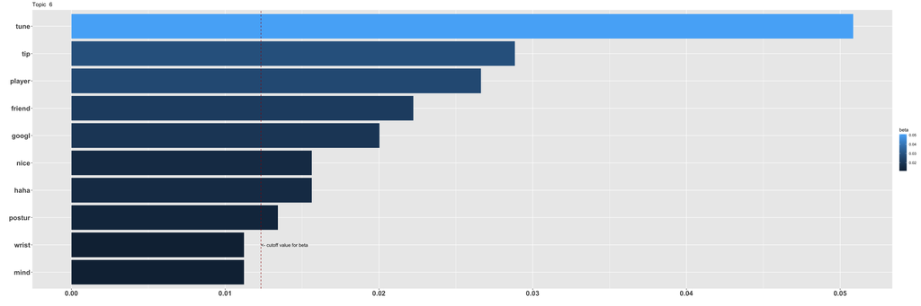

On interpreting beta: the term has a beta probability of being generated from the particular topic.

Values below are gamma : An estimated proportion of words from that document that are generated from that topic.

**Text Record Number: 404** gamma: 11 % likelihood of this document (based on its words) in this topic

**They don’t tune just the one key. They tune the whole piano so the keys are all in tune together. If you leave a piano untuned long enough, you can cause permanent damage, where the swelling and contracting of the wood makes the piano unable to be brought back into tune. Your tuner can let you know if they need to make multiple trips to slowly bring the piano back into tune, or if it can be tuned in one sitting.**

**Text Record Number: 400** gamma: 11 % likelihood of this document (based on its words) in this topic

**Chances are you have a tuning pin that is loose. Generally speaking all the strings/unisons will stay close to one another. Technicians can measure the torque of that pin. There are short term fixes for this like putting some thin CA glue around that tuning pin so it soaks into the pinblock. Again, not recommended but would be the cheapest option if indeed the tuning pin was loose.**

**Text Record Number: 1221** gamma: 11 % likelihood of this document (based on its words) in this topic

**I am taking a “fun” class this fall semester that starts late August. I am taking one heavy science class and thought I would add piano since I’ve always wanted to learn! And it would be a nice break from microbiology.  
We have a 100 year old piano in my house. My mom and I bought it on Craigslist or something years and years ago and had it tuned about 5 years ago. But no one in the house can play it lol Also should I have it tuned again?

So my question is, is there anything I can do now to start preparing for the class? Please note I don’t know ANYTHING about the technical sides of music or even playing as I play no instruments. This is the class description: This beginning course focuses on developing the skills needed for performing on piano, including reading from music notation, rhythm study, technique, expression, improvisation, harmonization, transposition, repertoire and style study**

**Text Record Number: 1182** gamma: 11 % likelihood of this document (based on its words) in this topic

**I honestly haven’t tried much metal, but if if you have a specific metal or rock song you think would be cool on keys I could try my hand at figuring out to emulate it.

A lot of it really is just listening to the feel and trying to emulate as much rhythm and accent as possible. Some combination of the drums, bass, and guitar essentially. It’s vastly different from tune to tune and a lot of them absolutely require you to create a composite rhythm between your two hands.**

**Text Record Number: 1199** gamma: 11 % likelihood of this document (based on its words) in this topic

**A failsafe way of dealing both with back pain, posture, and honestly just pain in general is strengthening your muscles. A lot of this type of pain is related to your muscles getting tired and cramping. Lifting heavy weights has made my life much more bearable (used to have real bad back pain every day).

Also, there isn’t any clear evidence that bad posture *leads* to back problems. This notion that there are “good” and “bad” postures has come under fire recently. What’s likely to be best is changing positions, moving, staying active. So yeah, don’t sit in the same posture the entire day. Obviously this only applies to health, not to playing piano - bad posture definitely leads to worse playing.**

**Text Record Number: 59** gamma: 11 % likelihood of this document (based on its words) in this topic

**I would get your piano tuned. It will make playing on it more enjoyable if it’s in tune.

You can learn a lot from most beginner piano books too. Your teacher will take you farther with showing correct technique, but if you want a head start you can use any adult beginner piano book.

Good luck! Have fun!**

**Text Record Number: 826** gamma: 11 % likelihood of this document (based on its words) in this topic

Baião is a Brazillian musical genre: https://en.wikipedia.org/wiki/Bai%C3%A3o_(music)  
I’m not a musician, but maybe it’s possible that this piece is an adaptation of Mozart’s Eine Kleine Nachtmusik in a Baião kinda of rhythm.